# Steam Game Success Prediction

This notebook builds and evaluates models to predict whether a Steam game will be "successful" using metadata from `steam_games.json` and review information from `australian_user_reviews.json`.

It is structured to match a typical workflow for Assignment 2 in DSC 158/258:

- Data loading and cleaning
- Feature engineering (per–game aggregates)
- Defining a target label for "success"
- Train/validation/test split
- Baseline models
- Improved models with feature engineering and hyperparameter tuning
- Evaluation and model selection
- Brief error analysis and takeaway summary

You should be able to run this notebook top–to–bottom after placing the JSON data files in the same directory.

```python
from sklearn.impute import SimpleImputer
from sklearn.feature_extraction.text import TfidfVectorizer
from sklearn.compose import ColumnTransformer
from sklearn.pipeline import Pipeline
from sklearn.preprocessing import StandardScaler
from sklearn.linear_model import LogisticRegression
from sklearn.ensemble import RandomForestClassifier, GradientBoostingClassifier
from sklearn.model_selection import train_test_split, GridSearchCV
from sklearn.metrics import (
    accuracy_score,
    precision_score,
    recall_score,
    f1_score,
    roc_auc_score,
    ConfusionMatrixDisplay,
    classification_report,
)
import matplotlib.pyplot as plt
import pandas as pd
import numpy as np
import ast
```

## 1. Data loading

We first load the two JSON line files provided for the project:

- `steam_games.json`: metadata for each game (id, name, price, genres, etc.)
- `australian_user_reviews.json`: nested per–user reviews; each line is a dictionary with a `user_id` and a `reviews` list.

We convert these to flat Pandas DataFrames and ensure that the `item_id` column is stored as string in both tables so we can merge them later.

```python
# Adjust the paths here if your data lives somewhere else
GAMES_PATH = "steam_games.json"
REVIEWS_PATH = "australian_user_reviews.json"

# ---- Load steam_games.json ----
games = []
with open(GAMES_PATH, "r", encoding="utf-8") as f:
    for line in f:
        line = line.strip()
        if not line:
            continue
        try:
            games.append(ast.literal_eval(line))
        except Exception as e:
            # If there are any malformed lines, just skip them
            print(f"Skipping bad line in games file: {e}")

games_df = pd.DataFrame(games)

# Make sure we have an item_id column as string
if "id" in games_df.columns and "item_id" not in games_df.columns:
    games_df = games_df.rename(columns={"id": "item_id"})
games_df["item_id"] = games_df["item_id"].astype(str)

print("Games shape:", games_df.shape)
games_df.head()

print(games_df.columns)
```

```
Games shape: (32135, 16)
Index(['publisher', 'genres', 'app_name', 'title', 'url', 'release_date',
       'tags', 'discount_price', 'reviews_url', 'specs', 'price',
       'early_access', 'item_id', 'developer', 'sentiment', 'metascore'],
      dtype='object')
```

```python
# ---- Load australian_user_reviews.json ----
reviews = []
with open(REVIEWS_PATH, "r", encoding="utf-8") as f:
    for line in f:
        line = line.strip()
        if not line:
            continue
        try:
            user_data = ast.literal_eval(line)
            user_id = user_data.get("user_id")
            for review in user_data.get("reviews", []):
                # Each review is a dict; copy it so we can safely mutate
                review_entry = dict(review)
                review_entry["user_id"] = user_id
                reviews.append(review_entry)
        except Exception as e:
            print(f"Skipping bad line in reviews file: {e}")

reviews_df = pd.DataFrame(reviews)

# Standardize the item id column
if "item_id" not in reviews_df.columns:
    # Some datasets call this appid, game_id, etc.; adjust if needed.
    for candidate in ["appid", "app_id", "id"]:
        if candidate in reviews_df.columns:
            reviews_df = reviews_df.rename(columns={candidate: "item_id"})
            break

reviews_df["item_id"] = reviews_df["item_id"].astype(str)

print("Reviews shape:", reviews_df.shape)
reviews_df.head()

print(reviews_df.columns)
```

```
Reviews shape: (59305, 8)
Index(['funny', 'posted', 'last_edited', 'item_id', 'helpful', 'recommend',
       'review', 'user_id'],
      dtype='object')
```

## 2. Quick EDA

We do a very light sanity check on the review and game data to make sure nothing looks wildly off and to understand rough distributions (e.g., review counts per game). You can expand this section if you want more detailed exploratory analysis for your writeup.

```
Unique games in games_df: 32133
Unique games in reviews_df: 3682

Reviews per game (head):
item_id
730       3759
440       3736
4000      1735
570       1562
218620    1137
Name: count, dtype: int64
```

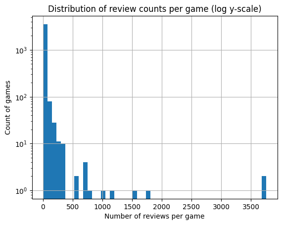

```python
# Number of unique games in each table
print("Unique games in games_df:", games_df["item_id"].nunique())
print("Unique games in reviews_df:", reviews_df["item_id"].nunique())

# Reviews per game
reviews_per_game = reviews_df["item_id"].value_counts()
print("\nReviews per game (head):")
print(reviews_per_game.head())

plt.figure()
reviews_per_game.hist(bins=50)
plt.xlabel("Number of reviews per game")
plt.ylabel("Count of games")
plt.yscale("log")
plt.title("Distribution of review counts per game (log y-scale)")
plt.show()
```

## 3. Feature engineering (per–game aggregates)

We aggregate the review–level data into game–level features. The exact fields present will depend on the provided JSON, but a common structure includes:

- `voted_up`: whether the review is positive (True/False or 1/0)
- `playtime_forever` or `author.playtime_forever`: hours played

From these we can build features such as:

- total review count
- share of positive reviews
- mean play time

We keep the code robust by checking which columns exist and gracefully skipping missing ones.

```python
POS_THRESHOLD = 0.75
MIN_REVIEWS_FOR_LABEL = 2

print("Reviews shape:", reviews_df.shape)
print("Review columns:", reviews_df.columns.tolist())

game_review_features = (
    reviews_df.groupby("item_id")
    .agg(
        n_reviews=("recommend", "size"),
        n_pos=("recommend", lambda s: (s == True).sum()),
    )
    .reset_index()
)

# Positive share: fraction of reviews that recommend the game
game_review_features["pos_share"] = (
    game_review_features["n_pos"] / game_review_features["n_reviews"]
)

# Binary success label from pos_share
game_review_features["success"] = (
    (game_review_features["n_reviews"] >= MIN_REVIEWS_FOR_LABEL)
    & (game_review_features["pos_share"] >= POS_THRESHOLD)
).astype(int)


# Log-transformed review count
game_review_features["log_n_reviews"] = np.log1p(game_review_features["n_reviews"])

# Keep what we need going forward
game_review_features = game_review_features[
    ["item_id", "n_reviews", "log_n_reviews", "pos_share", "success"]
]


print(game_review_features.head())
print("Game review feature shape:", game_review_features.shape)
print(game_review_features.describe())
```

```
Reviews shape: (59305, 8)
Review columns: ['funny', 'posted', 'last_edited', 'item_id', 'helpful', 'recommend', 'review', 'user_id']
  item_id  n_reviews  log_n_reviews  pos_share  success
0      10         57       4.060443   0.982456        1
1   10090         52       3.970292   0.980769        1
2   10130          2       1.098612   1.000000        1
3   10140          1       0.693147   1.000000        0
4   10150          9       2.302585   1.000000        1
Game review feature shape: (3682, 5)
         n_reviews  log_n_reviews    pos_share      success
count  3682.000000    3682.000000  3682.000000  3682.000000
mean     16.106735       1.567735     0.803689     0.433732
std     107.769088       1.140280     0.323680     0.495656
min       1.000000       0.693147     0.000000     0.000000
25%       1.000000       0.693147     0.727273     0.000000
50%       2.000000       1.098612     1.000000     0.000000
75%       6.000000       1.945910     1.000000     1.000000
max    3759.000000       8.232174     1.000000     1.000000
```

### 3.1 Basic game metadata features

We now pull a small set of useful metadata features out of `games_df`, such as:

- price
- release year (parsed from release date string, if available)
- number of genres / categories

You can expand this with more detailed parsing (e.g., full one–hot encodings of genres) if you want to push model performance further.

```python
games_features = games_df.copy()

# Ensure item_id is string for consistent merging
games_features["item_id"] = games_features["item_id"].astype(str)

# ----- Price (if present) -----
for col in ["price", "price_final", "initialprice"]:
    if col in games_features.columns:
        games_features[col] = pd.to_numeric(games_features[col], errors="coerce")
        games_features = games_features.rename(columns={col: "price"})
        break

if "price" not in games_features.columns:
    games_features["price"] = np.nan

# ----- Release year -----
year_col = None
for c in games_features.columns:
    if "release" in c.lower() and "date" in c.lower():
        year_col = c
        break

import re

def extract_year(x):
    if pd.isna(x):
        return np.nan
    digits = re.findall(r"(19\d{2}|20\d{2})", str(x))
    if digits:
        return int(digits[-1])
    return np.nan

if year_col is not None:
    games_features["release_year"] = games_features[year_col].apply(extract_year)
else:
    games_features["release_year"] = np.nan

# ----- Number of genres -----
if "genres" in games_features.columns:
    games_features["n_genres"] = games_features["genres"].astype(str).apply(
        lambda s: len([x for x in s.split(",") if x.strip()])
    )
else:
    games_features["n_genres"] = 0

# ----- Number of "categories" (we approximate with tags/specs if present) -----
if "tags" in games_features.columns:
    games_features["n_categories"] = games_features["tags"].astype(str).apply(
        lambda s: len([x for x in s.split(",") if x.strip()])
    )
elif "specs" in games_features.columns:
    games_features["n_categories"] = games_features["specs"].astype(str).apply(
        lambda s: len([x for x in s.split(",") if x.strip()])
    )
else:
    games_features["n_categories"] = 0

# ----- Text features for TF-IDF -----

# Identify possible text-like columns
text_cols = []
for col in ["genres", "tags", "specs", "title", "app_name"]:
    if col in games_features.columns:
        text_cols.append(col)

def clean_text_value(val):
    """Convert lists, arrays, floats, NaNs, or weird types into a clean string."""
    if isinstance(val, list) or isinstance(val, tuple):
        return " ".join(str(x) for x in val)
    if isinstance(val, dict):
        return " ".join(str(x) for x in val.values())
    # arrays from numpy
    if hasattr(val, "shape"):
        return " ".join(str(x) for x in val.tolist())
    if pd.isna(val):
        return ""
    return str(val)

def build_text(row):
    parts = []
    for c in text_cols:
        val = clean_text_value(row[c])
        parts.append(val)
    return " ".join(parts)

games_features["text_features"] = games_features.apply(build_text, axis=1)

# Keep only the columns we actually use
keep_cols = ["item_id", "price", "release_year", "n_genres", "n_categories", "text_features"]
games_features = games_features[keep_cols]

games_features.head()
```

|  | item_id | price | release_year | n_genres | n_categories | text_features |
| --- | --- | --- | --- | --- | --- | --- |
| 0 | 761140 | 4.99 | 2018.0 | 5 | 5 | Action Casual Indie Simulation Strategy Strate... |
| 1 | 643980 | NaN | 2018.0 | 4 | 19 | Free to Play Indie RPG Strategy Free to Play S... |
| 2 | 670290 | NaN | 2017.0 | 5 | 6 | Casual Free to Play Indie Simulation Sports Fr... |
| 3 | 767400 | 0.99 | 2017.0 | 3 | 3 | Action Adventure Casual Action Adventure Casua... |
| 4 | 773570 | 2.99 | NaN | 1 | 4 | Action Indie Casual Sports Single-player Full... |

### 3.2 Merge review aggregates with metadata

We merge the per–game review aggregates with the metadata features to obtain a single modeling table, one row per game.

```python
data = game_review_features.merge(games_features, on="item_id", how="inner")

# Drop 'price' if you’re not using it
if "price" in data.columns:
    data = data.drop(columns=["price"])

# Make sure text_features has no NaNs
data["text_features"] = data["text_features"].fillna("")

# --- Build modeling dataset WITHOUT review-based features ---

# Columns we do NOT want the model to use as inputs
review_cols = ["n_reviews", "log_n_reviews", "pos_share", "n_pos"]

# Make a copy just for modeling so original `data` is preserved
model_data = data.copy()

# Drop review-derived feature columns from the model data
model_data = model_data.drop(columns=[c for c in review_cols if c in model_data.columns])

# We will keep only:
# - release_year (numeric)
# - n_genres, n_categories (numeric)
# - text_features (TF-IDF input)
# - success (label)
print("Model data columns:", model_data.columns.tolist())
model_data.head()
```

```
Model data columns: ['item_id', 'success', 'release_year', 'n_genres', 'n_categories', 'text_features']
```

|  | item_id | success | release_year | n_genres | n_categories | text_features |
| --- | --- | --- | --- | --- | --- | --- |
| 0 | 10 | 1 | 2000.0 | 1 | 20 | Action Action FPS Multiplayer Shooter Classic ... |
| 1 | 10090 | 1 | 2008.0 | 1 | 20 | Action Zombies World War II FPS Action Multipl... |
| 2 | 10130 | 1 | 2007.0 | 1 | 13 | Action Action FPS Time Manipulation Sci-fi Fir... |
| 3 | 10140 | 0 | 2006.0 | 1 | 4 | Sports Sports Mini Golf Golf Local Multiplayer... |
| 4 | 10150 | 1 | 2009.0 | 2 | 20 | Action Adventure Action Open World Adventure T... |

## 4. Define the target: what is a "successful" game?

The dataset does not usually come with a pre–defined binary label for "success", so we need to define one. A simple choice is:

You are free to tweak these thresholds in your own experiments; just make sure you explain your reasoning in the writeup.

## 5. Train / validation / test split

We now split the data into training, validation, and test sets. For simplicity we use a two–step split:

You can also use cross–validation instead of a fixed validation split; we will demonstrate both approaches.

```python
# Features we want the model to see
numeric_features = ["release_year", "n_genres", "n_categories"]
text_feature = "text_features"

# Sanity check: make sure the columns exist
print("Numeric features present:", [c for c in numeric_features if c in model_data.columns])
print("Has text_features?", text_feature in model_data.columns)

# Build X and y
X = model_data[numeric_features + [text_feature]]
y = model_data["success"]

print("data shape:", model_data.shape)
print("X shape:", X.shape)
print("y shape:", y.shape)
print("success value counts:\n", y.value_counts(dropna=False))

# Train/val/test split
X_train, X_temp, y_train, y_temp = train_test_split(
    X, y, test_size=0.2, random_state=42, stratify=y
)

X_val, X_test, y_val, y_test = train_test_split(
    X_temp, y_temp, test_size=0.5, random_state=42, stratify=y_temp
)

print("Train size:", X_train.shape[0])
print("Val size:", X_val.shape[0])
print("Test size:", X_test.shape[0])
```

```
Numeric features present: ['release_year', 'n_genres', 'n_categories']
Has text_features? True
data shape: (3195, 6)
X shape: (3195, 4)
y shape: (3195,)
success value counts:
 success
0    1770
1    1425
Name: count, dtype: int64
Train size: 2556
Val size: 319
Test size: 320
```

## 6. Baseline models

Before building complex models, it is important to establish simple baselines:

These baselines give us a floor that our more complex models should beat.

```
Dummy (most frequent)
Accuracy:  0.555
Precision: 0.000
Recall:    0.000
F1:        0.000
ROC AUC:   0.500
```

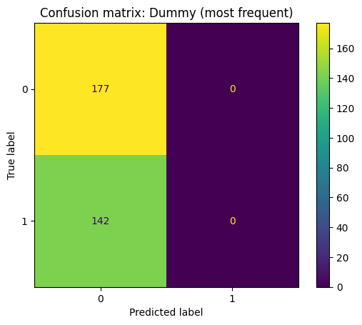

```
Classification report:
              precision    recall  f1-score   support

           0       0.55      1.00      0.71       177
           1       0.00      0.00      0.00       142

    accuracy                           0.55       319
   macro avg       0.28      0.50      0.36       319
weighted avg       0.31      0.55      0.40       319
```

```python
def evaluate_model(name, model, X_tr, y_tr, X_v, y_v):
    print(f"\n{name}")
    model.fit(X_tr, y_tr)
    y_pred = model.predict(X_v)
    y_proba = None
    try:
        y_proba = model.predict_proba(X_v)[:, 1]
    except Exception:
        pass

    acc = accuracy_score(y_v, y_pred)
    prec = precision_score(y_v, y_pred, zero_division=0)
    rec = recall_score(y_v, y_pred, zero_division=0)
    f1 = f1_score(y_v, y_pred, zero_division=0)
    print(f"Accuracy:  {acc:.3f}")
    print(f"Precision: {prec:.3f}")
    print(f"Recall:    {rec:.3f}")
    print(f"F1:        {f1:.3f}")

    if y_proba is not None:
        try:
            auc = roc_auc_score(y_v, y_proba)
            print(f"ROC AUC:   {auc:.3f}")
        except Exception as e:
            print("Could not compute ROC AUC:", e)

    disp = ConfusionMatrixDisplay.from_predictions(y_v, y_pred)
    disp.ax_.set_title(f"Confusion matrix: {name}")
    plt.show()

    print("\nClassification report:")
    print(classification_report(y_v, y_pred, zero_division=0))


from sklearn.dummy import DummyClassifier

dummy = DummyClassifier(strategy="most_frequent")
evaluate_model("Dummy (most frequent)", dummy, X_train[numeric_features], y_train, X_val[numeric_features], y_val)
```

```
Logistic Regression (TF-IDF + metadata)
Accuracy:  0.743
Precision: 0.695
Recall:    0.754
F1:        0.723
ROC AUC:   0.817
```

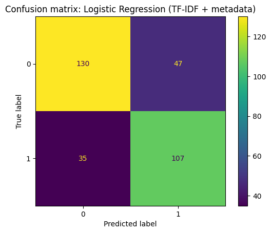

```
Classification report:
              precision    recall  f1-score   support

           0       0.79      0.73      0.76       177
           1       0.69      0.75      0.72       142

    accuracy                           0.74       319
   macro avg       0.74      0.74      0.74       319
weighted avg       0.75      0.74      0.74       319
```

```python
from sklearn.pipeline import Pipeline
from sklearn.compose import ColumnTransformer
from sklearn.impute import SimpleImputer
from sklearn.preprocessing import StandardScaler
from sklearn.feature_extraction.text import TfidfVectorizer

# Numeric pipeline: impute missing years, then scale
numeric_transformer = Pipeline(
    steps=[
        ("imputer", SimpleImputer(strategy="median")),
        ("scaler", StandardScaler()),
    ]
)

# Text pipeline: TF-IDF on genres/categories/tags/etc in text_features
text_transformer = TfidfVectorizer(
    max_features=5000,
    ngram_range=(1, 2),
)

# ColumnTransformer: numeric + text -> single feature matrix
preprocess = ColumnTransformer(
    transformers=[
        ("num", numeric_transformer, numeric_features),
        ("txt", text_transformer, text_feature),
    ],
    remainder="drop",
    sparse_threshold=0.0  # force dense output (helps GradientBoosting)
)

log_reg = Pipeline(
    steps=[
        ("preprocess", preprocess),
        ("clf", LogisticRegression(max_iter=1000, class_weight="balanced")),
    ]
)

evaluate_model("Logistic Regression (TF-IDF + metadata)", log_reg, X_train, y_train, X_val, y_val)
```

## 7. Improved models

We now try more flexible models, such as Random Forests and Gradient Boosting. These can capture non–linear interactions between features and often perform better on tabular datasets.

We use a small grid search over a handful of hyperparameters to avoid overfitting the validation set by hand–tuning too aggressively.

```
Fitting 3 folds for each of 8 candidates, totalling 24 fits
Best RF params: {'clf__max_depth': None, 'clf__min_samples_split': 2, 'clf__n_estimators': 200}
RF train accuracy: 0.6249790898359215

Random Forest (best, TF-IDF + metadata, no reviews)
Accuracy:  0.734
Precision: 0.728
Recall:    0.641
F1:        0.682
ROC AUC:   0.791
```

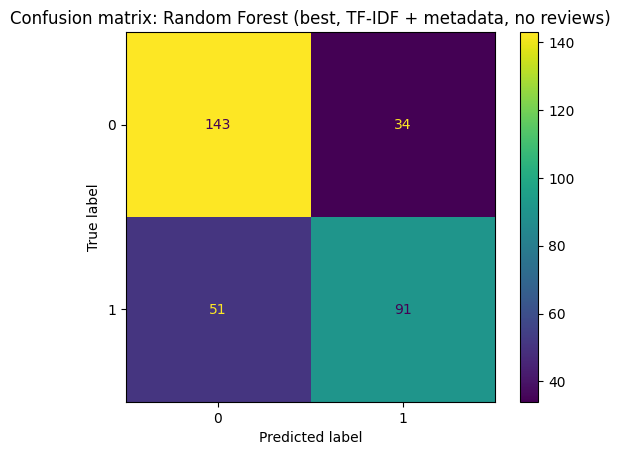

```
Classification report:
              precision    recall  f1-score   support

           0       0.74      0.81      0.77       177
           1       0.73      0.64      0.68       142

    accuracy                           0.73       319
   macro avg       0.73      0.72      0.73       319
weighted avg       0.73      0.73      0.73       319
```

```python
rf_pipeline = Pipeline(
    steps=[
        ("preprocess", preprocess),
        ("clf", RandomForestClassifier(random_state=42, n_jobs=-1)),
    ]
)

rf_param_grid = {
    "clf__n_estimators": [200, 400],
    "clf__max_depth": [None, 10],
    "clf__min_samples_split": [2, 5],
}

rf_grid = GridSearchCV(
    rf_pipeline,
    rf_param_grid,
    cv=3,
    scoring="f1",
    n_jobs=-1,
    verbose=1,
)

rf_grid.fit(X_train, y_train)
print("Best RF params:", rf_grid.best_params_)
print("RF train accuracy:", rf_grid.best_score_)  # CV score, not real train acc

best_rf = rf_grid.best_estimator_

evaluate_model("Random Forest (best, TF-IDF + metadata, no reviews)",
               best_rf, X_train, y_train, X_val, y_val)
```

```
Fitting 3 folds for each of 8 candidates, totalling 24 fits
Best GB params: {'clf__learning_rate': 0.1, 'clf__max_depth': 2, 'clf__n_estimators': 100}

Gradient Boosting (best CV, TF-IDF + metadata, no reviews)
Accuracy:  0.715
Precision: 0.689
Recall:    0.655
F1:        0.671
ROC AUC:   0.805
```

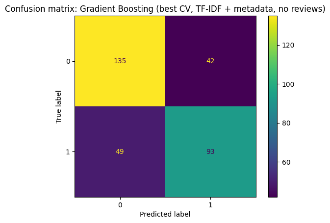

```
Classification report:
              precision    recall  f1-score   support

           0       0.73      0.76      0.75       177
           1       0.69      0.65      0.67       142

    accuracy                           0.71       319
   macro avg       0.71      0.71      0.71       319
weighted avg       0.71      0.71      0.71       319
```

```python
from sklearn.ensemble import GradientBoostingClassifier

gb_pipeline = Pipeline(
    steps=[
        ("preprocess", preprocess),
        ("clf", GradientBoostingClassifier(random_state=42)),
    ]
)

gb_param_grid = {
    "clf__n_estimators": [100, 200],
    "clf__learning_rate": [0.05, 0.1],
    "clf__max_depth": [2, 3],
}

gb_grid = GridSearchCV(
    gb_pipeline,
    gb_param_grid,
    cv=3,
    scoring="f1",
    n_jobs=-1,
    verbose=1,
)

gb_grid.fit(X_train, y_train)
print("Best GB params:", gb_grid.best_params_)

best_gb = gb_grid.best_estimator_

evaluate_model("Gradient Boosting (best CV, TF-IDF + metadata, no reviews)",
               best_gb, X_train, y_train, X_val, y_val)
```

## 8. Final model selection and test performance

Pick the model that looks best on the validation set (e.g., highest F1 or AUC) and evaluate it on the held–out test set. You may want to re–fit it on the combined train+validation data before testing; here we show that approach.

```
Final model performance on TEST set:
Accuracy:  0.725
Precision: 0.710
Recall:    0.650
F1:        0.679
ROC AUC:   0.803
```

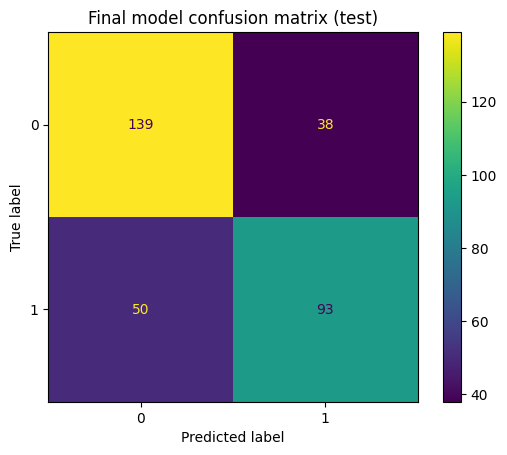

```
Classification report (test):
              precision    recall  f1-score   support

           0       0.74      0.79      0.76       177
           1       0.71      0.65      0.68       143

    accuracy                           0.72       320
   macro avg       0.72      0.72      0.72       320
weighted avg       0.72      0.72      0.72       320
```

```python
# Choose the best model based on validation performance.
# If Random Forest ends up better for you, swap in best_rf here.
final_model = best_gb

# Refit on train+val
X_train_full = pd.concat([X_train, X_val], axis=0)
y_train_full = pd.concat([y_train, y_val], axis=0)

final_model.fit(X_train_full, y_train_full)
y_test_pred = final_model.predict(X_test)
y_test_proba = final_model.predict_proba(X_test)[:, 1]

print("Final model performance on TEST set:")
acc = accuracy_score(y_test, y_test_pred)
prec = precision_score(y_test, y_test_pred, zero_division=0)
rec = recall_score(y_test, y_test_pred, zero_division=0)
f1 = f1_score(y_test, y_test_pred, zero_division=0)
auc = roc_auc_score(y_test, y_test_proba)

print(f"Accuracy:  {acc:.3f}")
print(f"Precision: {prec:.3f}")
print(f"Recall:    {rec:.3f}")
print(f"F1:        {f1:.3f}")
print(f"ROC AUC:   {auc:.3f}")

disp = ConfusionMatrixDisplay.from_predictions(y_test, y_test_pred)
disp.ax_.set_title("Final model confusion matrix (test)")
plt.show()

print("\nClassification report (test):")
print(classification_report(y_test, y_test_pred, zero_division=0))
```

## 10. Error analysis and discussion

The exact content of this section will go in your writeup, but you can use the code cells above to:

- Inspect misclassified games (e.g., games with high positive share but low predicted probability).
- Examine how performance changes when you vary the positive review threshold or the minimum review count.
- Compare different model families (logistic vs. tree–based).

Below is a small helper snippet to quickly look at a few false positives and false negatives for qualitative inspection.

```python
# Attach predictions back to the test DataFrame for inspection
test_with_meta = data.loc[X_test.index].copy()
test_with_meta["y_true"] = y_test.values
test_with_meta["y_pred"] = y_test_pred
test_with_meta["y_proba"] = y_test_proba

false_positives = test_with_meta[(test_with_meta["y_true"] == 0) & (test_with_meta["y_pred"] == 1)]
false_negatives = test_with_meta[(test_with_meta["y_true"] == 1) & (test_with_meta["y_pred"] == 0)]

print("False positives (head):")
display(false_positives.head())

print("\nFalse negatives (head):")
display(false_negatives.head())
```

```
False positives (head):
```

|  | item_id | n_reviews | log_n_reviews | pos_share | success | release_year | n_genres | n_categories | text_features | y_true | y_pred | y_proba |
| --- | --- | --- | --- | --- | --- | --- | --- | --- | --- | --- | --- | --- |
| 972 | 258970 | 9 | 2.302585 | 0.666667 | 0 | 2014.0 | 3 | 20 | Action Adventure RPG Co-op Dungeon Crawler Act... | 0 | 1 | 0.633122 |
| 6 | 10220 | 7 | 2.079442 | 0.142857 | 0 | 2011.0 | 1 | 20 | Action Action Dark Humor Gore Open World Third... | 0 | 1 | 0.824249 |
| 341 | 212200 | 9 | 2.302585 | 0.666667 | 0 | 2012.0 | 7 | 16 | Action Adventure Casual Free to Play Massively... | 0 | 1 | 0.553855 |
| 2800 | 444000 | 1 | 0.693147 | 1.000000 | 0 | 2016.0 | 4 | 17 | Indie Racing Simulation Sports Racing Sports I... | 0 | 1 | 0.584693 |
| 1394 | 293680 | 1 | 0.693147 | 1.000000 | 0 | 2012.0 | 3 | 17 | Adventure Indie RPG Visual Novel Female Protag... | 0 | 1 | 0.512533 |

```
False negatives (head):
```

|  | item_id | n_reviews | log_n_reviews | pos_share | success | release_year | n_genres | n_categories | text_features | y_true | y_pred | y_proba |
| --- | --- | --- | --- | --- | --- | --- | --- | --- | --- | --- | --- | --- |
| 2466 | 393410 | 7 | 2.079442 | 0.857143 | 1 | 2015.0 | 5 | 8 | Action Free to Play Indie Massively Multiplaye... | 1 | 0 | 0.219599 |
| 1521 | 304670 | 2 | 1.098612 | 1.000000 | 1 | 2014.0 | 3 | 5 | Casual Indie Strategy Strategy Indie Casual Sp... | 1 | 0 | 0.239578 |
| 532 | 2270 | 6 | 1.945910 | 1.000000 | 1 | 1994.0 | 1 | 12 | Action FPS Classic Action World War II Singlep... | 1 | 0 | 0.360273 |
| 701 | 239720 | 2 | 1.098612 | 1.000000 | 1 | 2013.0 | 1 | 4 | Action Action Platformer 3D Platformer Adventu... | 1 | 0 | 0.164463 |
| 156 | 18500 | 3 | 1.386294 | 1.000000 | 1 | 2008.0 | 2 | 11 | Indie Strategy Tower Defense Strategy Sci-fi I... | 1 | 0 | 0.382228 |

> **Next steps for your assignment writeup**

> In your separate writeup, you can now:
> - Clearly define your success label and motivate the thresholds you chose.
> - Describe the baselines and improved models you implemented.
> - Compare validation and test performance, highlighting any overfitting.
> - Reflect on which features matter most and why.
> - Discuss at least one limitation of this approach and how you would extend it (e.g., adding review text features, using more advanced models, etc.).